# cyanoMon2015Documentation

Bryan

May 18, 2015

## Readme

This document is available here: https://github.com/willbmisled/Reg1Cyano/blob/master/Access/cyanoMon2015Documentation.md

## To Do List

- Build forms-with data validation steps
- Interface for Phone App
  - Make sure ID structure is the same between database and phoneApp
- Remove field “organization” from tblSample. This is now in tblOrganization

## Question

- Do we remove the field “filtered”?
- Should we add table for lab results and ancillary data-toxins, nutrients, secchi, etc.?
- How do we keep track of what method was used to enter the data?
- Do we want to keep track of which Fluorometers are used (i.e, assign each unit a code)?
- Do we need to capture information on primary and secondary standards?
- How can we capture and archive the photos?
- Who owns the data? Where will it be stored? Are there access restrictions?

## Changes for the 2015 database

**tblWaterbody**

- removed field “otherWaterbodyID”
- changed commentWB to format “Long Text” to allow for multiple comments

**tblStation**

- removed field “otherStationID”
- changed commentSta to format “Long Text” to allow for multiple comments
- renamed “stationLocation” to “stationDescription” to match phoneApp

**tblSample**

- added field “sampleRep” to register replicate samples: with default value “primary” and optional value “duplicate”

**tblFluorometry**

- table removed and fields added to tblAnalysis

**tblAnalysis**

- added fields from tblFluorometry
  - “parameter”
  - “fluorometerType”
  - “rep” renamed “analysisRep”: with default value “primary” and optional value “duplicate”
  - “reading” renamed “valueUGL”
- fields that were not transferred from from tblFluorometry
  - fluorometryID
  - commentFluorometry
  - units

## Background

- EPA region 1 is coordinating a Cyanobacteria Monitoring Progam for the six New England States (CT, MA, ME, NH, RI, & VT)
- Data collection initiated during the summer of 2014
- 2014 data have been collated and standardized
- For future data collection we need a relational database developed for data entry and archiving
- The Database needs to work with a Data Collection Phone App under development
- The database will be created in MSAccess (cyanoMon2015.mdb)

## Database Structure

- The relationships between the tables are shown in the figure below

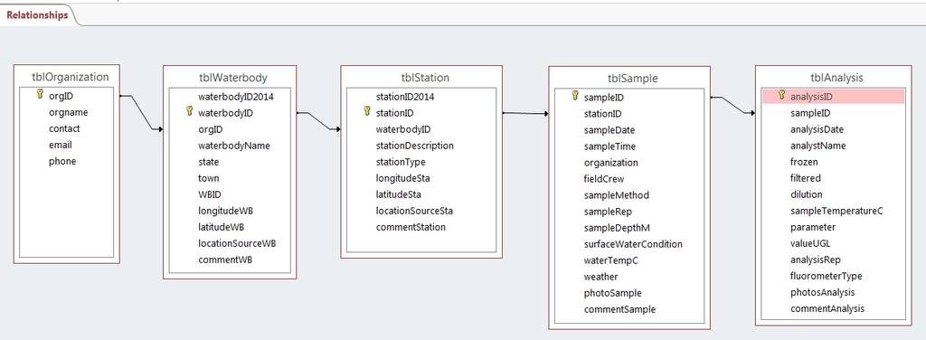

- Each table in the access database (cyanoMon2015.mdb) is described and data definitions are given below

**tblOrganization** provides contact information for each organization contributing to the monitoring.

[output not shown]

**tblWaterbody** provides general information on the waterbody and assigns a unique identifier. Ideally we will have this table populated before the field crews go out so that they can select the correct lake from a list. The reality is that we will also need to be able to add lakes on the fly as new lakes are added to the sampling plan. There may be multiple stations for each waterbody.

| Field | Data Type | Description |
| --- | --- | --- |
| **waterbodyID2014** | Short Text | In some cases the waterbodyID was changed between 2014 and 2015. If they are different the 2014 ID is listed in this table. This field will not be included in data entry forms. |
| **waterbodyID** | Short Text | Primary Key for this table. Unique ID for the Waterbody. Can either be entered by the users or or assigned by the phoneApp. |
| **orgID** | Short Text | Lookup primary Key from tblOrganization |
| **waterbodyName** | Short Text | Name of the waterbody |
| **state** | Short Text | Combo Box (“CT”; “MA”; “ME”; “NH”; “RI”; “VT”): Two letter state abbreviations |
| **town** | Short Text | Text Box: Closest town to the lake |
| **WBID** | Long Integer | Text Box: EPA Waterbody Identifier; Not in phoneApp. This field will be populated by the database administrator. |
| **longitudeWB** | Double | Text Box: longitude in decimal degrees (WGS84) of the lake centroid. This field will be populated by the database administrator. |
| **latitudeWB** | Double | Text Box: latitude in decimal degrees (WGS84) of the lake centroid. This field will be populated by the database administrator. |
| **locationSourceWB** | Short Text | Combo Box (“WaterbodyDatabase”; “GPS”; “GoogleEarth”; “BingMaps”; “topoMap”): How was the location determined? This field will be populated by the database administrator. |
| **commentWB** | Long Text | Text Box: Additional information or comments |

**tblStation** within each Waterbody there may be multiple stations. This table provides general information on the station. There may be multiple samples taken from each station. Note: this table was first made from tblStation in Data2014.mdb. A query (qryMaketblStation2015) the table (temp_tblStation2015). This table is essentially the same except that the field “stationLocation” was renamed “stationDescription” if “stationLocation” was blank the field “otherStationID” was substituted.

| Field | Data Type | Description |
| --- | --- | --- |
| **stationID2014** | Short Text | In some cases the stationID was changed between 2014 and 2015. If they are different the 2014 ID is listed in this table. This field will not be included in data entry forms. |
| **stationID** | Short Text | Primary Key for this table. Unique ID for the Station |
| **waterbodyID** | Short Text | Lookup primary Key from tblWaterbody |
| **stationDescription** | Short Text | Text description of the station location |
| **stationType** | Short Text | List Box/Radio Button (“nearShore”; “offShore”;“other”): Location of the station in relation to the shore;for special situations choose other and add notes in field “commentStation” |
| **longitudeSta** | Double | Text Box: longitude in decimal degrees (WGS84) of the station. Miniumum of 4 decimal places; 6 decimal places prefered. |
| **latitudeSta** | Double | Text Box: latitude in decimal degrees (WGS84) of the station. Miniumum of 4 decimal places; 6 decimal places prefered. |
| **locationSourceSta** | Short Text | Combo Box (“WaterbodyDatabase”; “GPS”; “GoogleEarth”; “BingMaps”; “topoMap”): How was the location determined? |
| **commentStation** | Long Text | Text Box: Additional information or comments |

**tblSample** for each station within a waterbody there may be multiple sample events. This table provides general information on each sample event. There may be multiple analysis events for each sample event.

| Field | Data Type | Description |
| --- | --- | --- |
| **sampleID** | Short Text | Primary Key for this table. Unique ID for the sample event |
| **stationID** | Short Text | Lookup primary Key from tblStation: where was the sample taken? |
| **sampleDate** | Short Date | Text Box: Date the sample was taken in format MM/DD/YYYY |
| **sampleTime** | Medium Time | Text Box: Time the sample was taken in format HH:MM AM/PM |
| **fieldCrew** | Short Text | Text Box: Names of the field crew separated by commas |
| **sampleMethod** | Short Text | Combo Box (“Integrated Sampler”): should be Integrated Sampler but other values can be added. |
| **sampleRep** | Short Text | Option to choose between “primary” (default) and “duplicate”. Note: a sample rep should be a completely new sample not just a subsample from the original sample. |
| **sampleDepthM** | Integer | Combo Box (1; 3): Depth (meters) sample was taken. Should be 1 or 3 meters but other values can be added. |
| **waterTempC** | Single | Text Box: Lake water temperature in Celsius |
| **weather** | Short Text | List Box (“Clear”; “Partly Cloudy”; “Overcast”; “Rain”): Limited choice descriptor of weather conditions |
| **surfaceWaterCondition** | Short Text | List Box (“Calm”; “Ripples”; “Choppy”; “White Caps”): Limited choice descriptor of weather conditions |
| **photoSample** | Yes/No | Check Box: where photos taken during sampling? |
| **commentSample** | Long Text | Text Box: Additional information or comments |

**tblAnalysis** for each sample taken there will be one or more analysis events. This table provides general information on each analysis event.

| Field | Data Type | Description |
| --- | --- | --- |
| **analysisID** | Short Text | Primary Key for this table. Unique ID for the analysis event |
| **sampleID** | Short Text | Lookup primary Key from tblSample: analysis for which sample event? |
| **analysisDate** | Short Date | Text Box: Date the sample was analyzed in format MM/DD/YYYY |
| **analystName** | Short Text | Text Box: Name of primary person in charge of the analysis |
| **frozen** | Yes/No | Check Box: was sample frozen prior to analysis? |
| **filtered** | Yes/No | Check Box: was sample filtered prior to analysis? |
| **dilution** | Short Text | Combo Box (“1:1”; “1:5”; “1:10”): Default = 1 to 1 (not diluted); other choices are 1 to 5 and 1 to 10; other values can also be added. |
| **sampleTemperatureC** | Single | Text Box: sample temperature in Celsius at time of analysis |
| **parameter** | Short Text | List Box/Radio Button (“phycocyanin”; “chlorophyll”) |
| **valueUGL** | Single | Text Box: Fluorometry reading |
| **analysisRep** | Short Text | Option to choose between “primary” (default) and “duplicate”. Note: this should be a reading of a new aliquot from the sample; not a duplicate reading of a previously read aliquot. |
| **fluorometerType** | Combo Box: (“Beagle”): this should be a Beagle but user can input other choices. |  |
| **photoAnalysis** | Yes/No | Check Box: where photos taken during analysis? |
| **commentAnalysis** | Long Text | Text Box: Additional information or comments |